# DATA583 Final Project Report

Matthew Yau, ZiYing(Sophie) Chen, Xinyu Dong

2023-03-24

## Introduction

Heart disease is a leading cause of death worldwide. Due to the potential for heart disease to cause negative effects, such as death, it may be important to investigate ways to prevent heart disease.

One way to prevent heart disease is to examine the risk factors for heart disease. Understanding risk factors may help prevent heart disease development because, for example, it may allow medical practitioners to identify individuals who are susceptible to developing heart disease. After identification, early preventative interventions could be applied to this high-risk group, reducing the likelihood of heart disease.

## Research Questions and Hypotheses

Therefore, the aim of the current investigation is to investigate the factors that contribute to the development of heart disease. More specifically, we investigate the three following questions:

1. What lifestyle variables are related to the diagnosis of heart disease?
2. What variables are most important to the diagnosis of heart disease?
3. What groups of people are most likely to develop heart disease?

To investigate the first two questions, we will conduct logistic regression analysis. To investigate the third question, we will use decision trees.

We hypothesize that, based on previous research (Ryo, Cho & Kim, 2012), that a number of variables (e.g. body mass index, smoking habits) will be related to heart disease. Furthermore, we will investigate the questions of identifying importance of coefficients, and identification of high risk groups for heart disease in an exploratory manner.

## Methods and Dataset

The dataset on Kaggle (Pytlak, 2022) was filtered to contain only variables related to heart disease, resulting in 18 heart-disease related factors, and cleaned (e.g. missing values were removed), resulting in 319,795 responses with no missing values. Amongst the dataset of 319,795 responses we obtained on Kaggle, 18,078 duplicate responses were found and removed, resulting in a final sample size of 301,717 observations.

Table 1: Variables in the Dataset

| Variable Name | Questionnaire | Data Type | Observed distribution |
| --- | --- | --- | --- |
| **HeartDisease** | Have you ever had coronary heart disease or myocardial infection in your life? | Binary (yes, no) | Imbalanced binary (9% yes, 91% no) |
| **BMI** | What is your body mass index? | Continuous | Normal (mean = 28.3, variance = 40) |
| **Smoking** | Have you smoked at least 100 cigarettes in your entire life? | Binary (Yes, no) | Binary (59% no, 41% yes) |
| **AlcoholDrinking** | Do you drink heavily? (Men: more than 14 drinks a week, women: more than 7 drinks a week) | Binary (Yes, no) | Imbalanced binary (7% yes, 93% no) |
| **Stroke** | Have you ever had a stroke? | Binary (Yes, no) | Imbalanced binary (4% yes, 96% no) |
| **PhysicalHealth** | Thinking about your physical health, which includes physical illness and injury, for how many days during the past 30 days was your physical health not good? | Discrete (0-30 days) | Poisson (lambda = 3.3) |
| **MentalHealth** | Thinking about your mental health, for how many days during the past 30 days was your mental health not good? | Discrete (0-30 days) | Poisson (lambda = 3.9) |
| **DiffWalking** | Do you have serious difficulty walking or climbing stairs? | Binary (Yes, no) | Imbalanced binary (14% yes, 86% no) |
| **Sex** | Are you male or female? | Binary (Yes, no) | Binary (48% Male, 52% Female) |
| **AgeCategory** | What is your age group? | Ordinal categorical (e.g. less than 40, 40-59, 60-79, greater than 80) | Normal |
| **Race** | What is your race? (recoded to binary variable) | Binary (White, non-white) | Imbalanced binary (77% white, 23% non-white) |
| **Diabetic** | Have you ever had diabetes? | Nominal categorical (No, borderline diabetes, yes, yes (during pregnancy)) | Positive skew (86% no, 14% non-no) |
| **PhysicalActivity** | Have you had physical activity or exercise during the past 30 days other than their regular job | Binary (Yes, no) | Imbalanced binary (78% yes, 22% no) |
| **GenHealth** | Would you say your health in general is | Ordinal categorical (Poor, fair, good, very good) | Negative skew (poor 4%, fair 10%) |
| **SleepTime** | On average, how many hours of sleep do you get in a 24-hour period? | Continuous | Normal (mean = 7, variance = 2) |
| **Asthma** | Have you ever had asthma? | Binary (Yes, no) | Imbalanced binary (14% yes, 86% no) |
| **KidneyDisease** | Have you ever had kidney disease (not including kidney stones, bladder infections)? | Binary (Yes, no) | Imbalanced binary (4% yes, 96% no) |
| **SkinCancer** | Have you ever had skin cancer? | Binary (Yes, no) | Imbalanced binary (9% yes, 91% no |

## Logistic Regression Analysis

Logistic regression is a statistical method used to analyze and model relationships between a binary dependent variable (i.e., one that takes on only two values, such as 0 or 1) and one or more independent variables (also known as predictors or explanatory variables). It is a type of regression analysis that is used to predict the probability of an event occurring based on the values of the independent variables.

### Model Fitting

Interaction term shows that one’s effect on response variable depends on the other, with only one of the variable might not have predictive power, but combine them together, we can predict. Based on our EDA, we add interaction terms of *AgeCategory* * *Sex* and *AgeCategory* * *Race* as our full model.

The formula of our logistic models are:

Model1: Without interaction terms

```
## HeartDisease ~ BMI + Smoking + AlcoholDrinking + Stroke + PhysicalHealth +
##     MentalHealth + DiffWalking + Sex + AgeCategory + Race + Diabetic +
##     PhysicalActivity + GenHealth + SleepTime + Asthma + KidneyDisease +
##     SkinCancer
```

Model2: With the interaction terms

```
## HeartDisease ~ BMI + Smoking + AlcoholDrinking + Stroke + PhysicalHealth +
##     MentalHealth + DiffWalking + Sex + AgeCategory + Race + Diabetic +
##     PhysicalActivity + GenHealth + SleepTime + Asthma + KidneyDisease +
##     SkinCancer + Race * AgeCategory + Sex * AgeCategory
```

### Goodness of Fit Tests

In logistic regression, we can perform an overall goodness-of-fit test using the likelihood ratio test, which compares the full model to a reduced model without the predictors of interest. The test is based on the difference in deviances between the full model and the reduced model, and it follows a chi-squared distribution with degrees of freedom equal to the difference in the number of parameters between the two models.

The null hypothesis of the likelihood ratio test is that the reduced model fits the data as well as the full model. And the alternative hypothesis is that the full model fits the data significantly better than the reduced model.

According to the goodness of fit test, we choose the model with interaction term.

|  | Resid. Df | Resid. Dev | Df | Deviance | Pr(>Chi) |
| --- | --- | --- | --- | --- | --- |
| 1 | 301692 | 144563.7 | NA | NA | NA |
| 2 | 301686 | 144371.0 | 6 | 192.6441 | 6.971058e-39 |

### Variable Selection

To get a simpler model, we decided to perform the backward elimination stepwise selection based on the AIC. Stepwise selection is a statistical method to identify the best subset of predictors in a regression model. Backward elimination will remove the predictor one by one based on their contribution.

The models before and after are listed below:

Model_full:

```
## HeartDisease ~ BMI + Smoking + AlcoholDrinking + Stroke + PhysicalHealth +
##     MentalHealth + DiffWalking + Sex + AgeCategory + Race + Diabetic +
##     PhysicalActivity + GenHealth + SleepTime + Asthma + KidneyDisease +
##     SkinCancer + Race * AgeCategory + Sex * AgeCategory
```

Model_select:

```
## HeartDisease ~ BMI + Smoking + AlcoholDrinking + Stroke + DiffWalking +
##     Sex + AgeCategory + Race + Diabetic + GenHealth + SleepTime +
##     Asthma + KidneyDisease + SkinCancer + AgeCategory:Race +
##     Sex:AgeCategory
```

*PhysicalHealth*, *MentalHealth*, and *PhysicalActivity* are removed from the process.

### Model Diagnosis

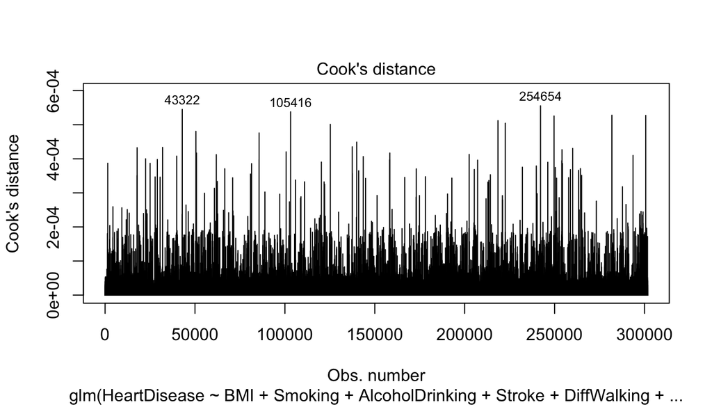

Figure 1: Cook’s Distance

### Research Questions 1

- Question 1: What lifestyle variables are related to heart disease?

```
##
## Call:
## glm(formula = HeartDisease ~ BMI + Smoking + AlcoholDrinking +
##     Stroke + DiffWalking + Sex + AgeCategory + Race + Diabetic +
##     GenHealth + SleepTime + Asthma + KidneyDisease + SkinCancer +
##     AgeCategory:Race + Sex:AgeCategory, family = "binomial",
##     data = heart_2020)
##
## Deviance Residuals:
##     Min       1Q   Median       3Q      Max
## -2.2055  -0.4248  -0.2550  -0.1440   3.4318
##
## Coefficients:
##                                   Estimate Std. Error z value Pr(>|z|)
## (Intercept)                      -5.497238   0.085564 -64.247  < 2e-16 ***
## BMI                               0.004442   0.001122   3.958 7.57e-05 ***
## SmokingYes                        0.355490   0.014350  24.773  < 2e-16 ***
## AlcoholDrinkingYes               -0.301387   0.033386  -9.027  < 2e-16 ***
## StrokeYes                         1.062048   0.022539  47.121  < 2e-16 ***
## DiffWalkingYes                    0.258676   0.017407  14.860  < 2e-16 ***
## SexMale                           0.168612   0.072421   2.328 0.019901 *
## AgeCategory40-59                  0.955375   0.076802  12.439  < 2e-16 ***
## AgeCategory60-79                  1.499783   0.073860  20.306  < 2e-16 ***
## AgeCategory80 or older            2.104839   0.088016  23.914  < 2e-16 ***
## RaceWhite                        -0.109620   0.074063  -1.480 0.138848
## DiabeticNo, borderline diabetes   0.126777   0.041590   3.048 0.002302 **
## DiabeticYes                       0.492763   0.016639  29.616  < 2e-16 ***
## DiabeticYes (during pregnancy)   -0.002830   0.103909  -0.027 0.978275
## GenHealthFair                     1.492174   0.031914  46.756  < 2e-16 ***
## GenHealthGood                     1.001524   0.029545  33.898  < 2e-16 ***
## GenHealthPoor                     1.924925   0.037098  51.888  < 2e-16 ***
## GenHealthVery good                0.470601   0.030477  15.441  < 2e-16 ***
## SleepTime                        -0.016575   0.004278  -3.874 0.000107 ***
## AsthmaYes                         0.240207   0.019076  12.592  < 2e-16 ***
## KidneyDiseaseYes                  0.582908   0.024295  23.993  < 2e-16 ***
## SkinCancerYes                     0.144511   0.019462   7.425 1.13e-13 ***
## AgeCategory40-59:RaceWhite        0.182002   0.081385   2.236 0.025331 *
## AgeCategory60-79:RaceWhite        0.449211   0.078116   5.751 8.89e-09 ***
## AgeCategory80 or older:RaceWhite  0.509895   0.092021   5.541 3.01e-08 ***
## SexMale:AgeCategory40-59          0.354893   0.078693   4.510 6.49e-06 ***
## SexMale:AgeCategory60-79          0.628598   0.074722   8.412  < 2e-16 ***
## SexMale:AgeCategory80 or older    0.443751   0.079873   5.556 2.77e-08 ***
## ---
## Signif. codes:  0 '***' 0.001 '**' 0.01 '*' 0.05 '.' 0.1 ' ' 1
##
## (Dispersion parameter for binomial family taken to be 1)
##
##     Null deviance: 183054  on 301716  degrees of freedom
## Residual deviance: 144388  on 301689  degrees of freedom
## AIC: 144444
##
## Number of Fisher Scoring iterations: 7
```

### Research Questions 2

- Question 2: What variables are most important to the development of heart disease?

In the logistic regression model, the estimated coefficients represent the change in the log-odds of the outcome associated with a one-unit increase in the predictor variable, holding other variables constant. Variables with larger coefficients (absolute value) are generally considered more important. But we should combine the p-value of them to see if the association is real or by chance (big p-value).

According to the summary of the stepwise model, *AgeCategory80 or older*, *GenHealthPoor*, *AgeCategory60-79*, and *GenHealthFair* are the most important variables indicators for heart disease (please refer to the coefficients and p-values in the following Table 2.)

Table 2: Important Variables in the Logistic Regression Model

[output not shown]

## Decision Tree Analysis

To examine what groups of people are most likely to develop heart disease, we ran a decision tree classifier model. We chose to run this model because decision trees provide easy and practical boundaries, allowing us to identify groups of patients that are most likely to develop heart disease.

### Model Fitting

To examine high risk groups using decision trees, we followed these broad steps. First, we found the optimal decision tree for the dataset using 10-fold cross validation (cutting the tree at the optimal node size resulting from this process). Second, based off this tree, we distinguish between groups that have high risk of heart disease, and we filter the dataset to specifically examine group features that are at risk of developing heart disease. We repeat steps 1 and 2 until we find that the probability of a group having heart disease is above 50%. In total, the decision tree analysis process was repeated two times, described below.

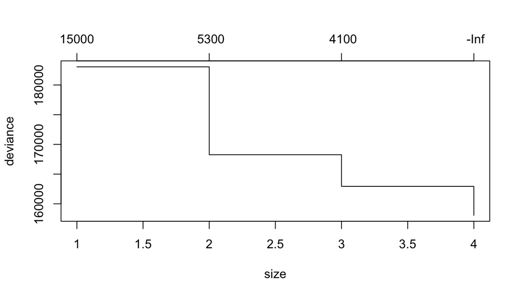

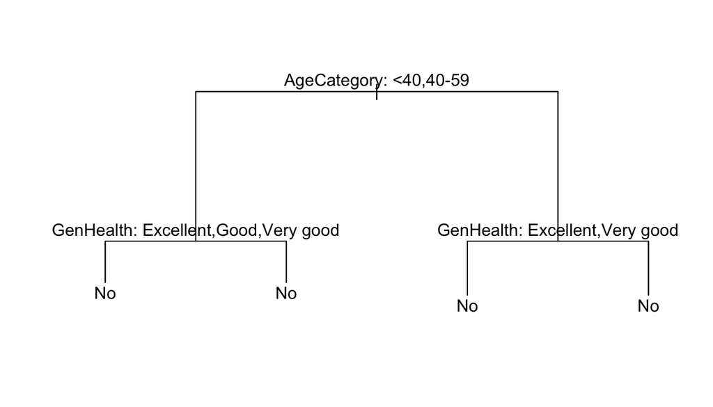

Figure 2.2: Decision Tree for Heart Disease on the Whole Dataset

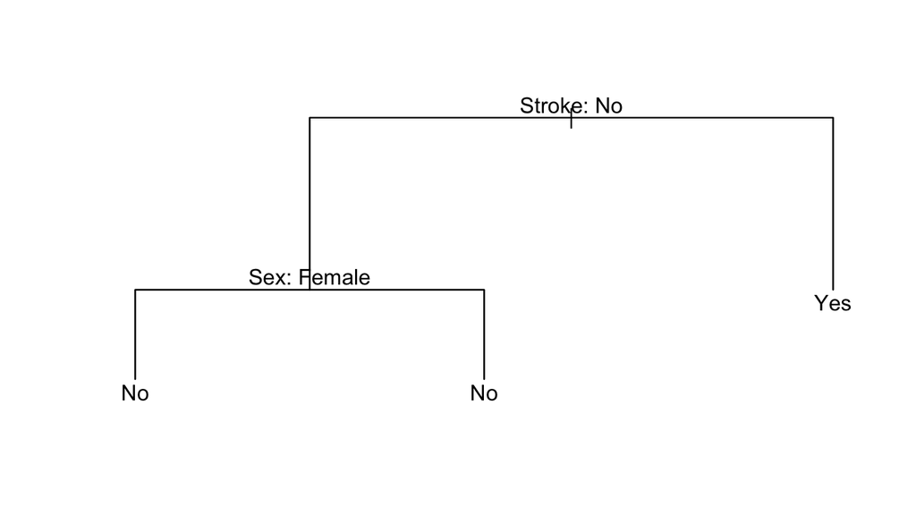

Figure 2.3: Decision Tree on Heart Disease for at risk Groups

In the second step of the process, we repeat fitting of the decision tree model to the high risk group. Plotting the optimal tree (Figure 2.3; node size determined by cross validation), we identify another important feature of stroke history. In the high risk group, if there was no prior history of stroke, the decision tree predicts that the absence of a heart attack. In contrast, in the high risk group, if there was prior history of stroke, the risk of having heart disease increases from 31.10% to 50.67%.

### Research Question 3

- Question 3 What groups of people are most likely to develop heart disease?

Table 3: Identifying High Risk Groups for Development of Heart Disease

[output not shown]

## Conclusion

Taken together, the findings from the current investigation identified, in a large-scale and representative sample of residents in the United States, risk factors that may contribute to the development of heart disease, findings of which may have implications for the real world, such as informing medical practitioners.

[output not shown]

## Limitations and Future Directions

While the present investigation yielded several insights into the risk factors related to heart disease, it should be noted that there were also a number of limitations.

One limitation is that, although our investigation yielded a large number of significant risk factors linked to heart disease, the factors within this investigation is only able to explain a weak proportion of the variation in heart disease, with an adjusted R-squared of **0.2** (though see Ryo et al., 2012 for similar R-squared values). In other words, though risk factors were identified, these risk factors may be less relevant because they may not be the main driving factors behind heart disease onset.

Why may there be a low R-squared value? There may be a variety of reasons. For one, it is possible that the methods of the current investigation may contribute to a low R-squared value. For example, it is possible that that the current investigation fails to capture important predictor variables (e.g. biological or genetic markers) that are relevant to heart disease onset, to explain for the low variation explained in heart disease. Furthermore, it is also possible that the subjective nature of the methodology (e.g. telephone survey, self-reported heart disease, retrospective self-reports of exercise history) may hinder the extent to which explanatory variables can be related to response variables, compared to more objective measures of heart disease (e.g. biological measurements of heart disease). Future work could improve upon methodology (e.g., obtaining objective measurements of heart disease) when investigating risk factors for heart disease.

Second, it is also possible that the current modelling techniques may be the result of low R-squared values. For example, diagnostic plots during the fitting of logistic regression models showed that there were a high number of influential points (e.g. potentially due to a large number of imbalanced binary predictors), of which violates one of the assumptions of logistic regression models (that is, lack of influential points) and contributing to poor fit. Furthermore, another factor that may account for poor model fit of logistic regression models is imbalanced response variables. In the future, alternative modelling techniques should be considered, such as using models (e.g. generalized additive models) and methods (e.g. oversampling; Ustyannie & Suprapto, 2020) that are less susceptible to imbalanced predictors and response variables.

## References

Pytlak, K. (2022, February 16). Personal key indicators of heart disease. Kaggle. Retrieved March 24, 2023, from https://www.kaggle.com/datasets/kamilpytlak/personal-key-indicators-of-heart-disease

Ryoo, J.-H., Cho, S. H., & Kim, S.-W. (2012). Prediction of risk factors for coronary heart disease using Framingham risk score in Korean men. PLoS ONE, 7(9). https://doi.org/10.1371/journal.pone.0045030

Ustyannie, W., & Suprapto, S. (2020). Oversampling method to handling imbalanced datasets problem in binary logistic regression algorithm. IJCCS (Indonesian Journal of Computing and Cybernetics Systems), 14(1), 1. https://doi.org/10.22146/ijccs.37415